# Machine Learning for Microbial Genomics

Janani Ravi | jravilab.github.io

2023-08-01

# MLHD @ICTS | Aug 02, 2023

> This is a companion repo & webpage for the Microbial Genomics and ML workshop, first presented at the MLHD 2023 conference! You can access the material here: https://github.com/jananiravi/2023-mlhd

## Overview

> This session will cover ideas, concepts, and insights needed to get started with building machine learning models with high-dimensional data, such as microbial genomics. No prior knowledge in ML is required.

### Acknowledgments

- JRaviLab: Jacob Krol, Ethan Wolfe, Evan Brenner, Keenan Manpearl, Joseph Burke, Vignesh Sridhar, Jill Bilodeaux
- Arjun Krishnan
- R-Ladies, esp. R-Ladies East Lansing, R-Ladies Aurora
- `tidymodels` resource by Julia Silge et al.,

## Install and load packages

To use the code in this document, you will need to install the following packages: `glmnet`, `tidyverse`, and `tidymodels`.

```r
library(tidyverse)
library(tidymodels)
library(glmnet)
```

## Explore your data

Here, we will use microbial genomics data (i.e., gene presence/absence across multiple microbial genomes) wrangled and processed from the [Bv-BRC](https://bv-brc.org/) to predict the antibiotic resistance phenotype of each sample (genome) based on the presence/absence of genes in that sample.

### Read in the data file

```r
#gpa-feature-matrix.tsv
exp_featmat <- read_delim("../data/staph_penicillin_pangenome.csv",
                          delim = ",", col_names = T)
```

### Data exploration

Let’s print the tibble to examine it quickly.

```r
exp_featmat
```

```
## # A tibble: 920 × 2,328
##     s_no genome_id antibiotic amr_pheno   drug_class assembly_accession  prmA
##    <dbl>     <dbl> <chr>      <chr>       <chr>      <chr>              <dbl>
##  1     0     1280. penicillin Susceptible penicillin GCA_024925485.1        1
##  2     1     1280. penicillin Susceptible penicillin GCA_024925485.1        1
##  3     2     1280. penicillin Susceptible penicillin GCA_024972975.1        1
##  4     3     1280. penicillin Susceptible penicillin GCA_024972975.1        1
##  5     4     1280. penicillin Resistant   penicillin GCA_025232045.1        1
##  6     5     1280. penicillin Resistant   penicillin GCA_025232045.1        1
##  7     6    46170. penicillin Resistant   penicillin GCA_002204575.1        1
##  8     7     1280. penicillin Susceptible penicillin GCA_002089075.2        1
##  9     8     1280. penicillin Resistant   penicillin GCA_002089095.2        1
## 10     9     1280. penicillin Resistant   penicillin GCA_002097595.2        1
## # ℹ 910 more rows
## # ℹ 2,321 more variables: hisC_1 <dbl>, araB <dbl>, yqeN <dbl>, tagH_2 <dbl>,
## #   `tet(38)` <dbl>, lrgB <dbl>, cmtB <dbl>, scmP_2 <dbl>, est_2 <dbl>,
## #   glcB <dbl>, ponA <dbl>, clpX <dbl>, yiiM <dbl>, thiN <dbl>, ilvE <dbl>,
## #   ydcV <dbl>, menH <dbl>, relA <dbl>, yicL <dbl>, rho <dbl>, guaA <dbl>,
## #   hemB <dbl>, hemA <dbl>, glpQ_1 <dbl>, suhB <dbl>, tatC2 <dbl>, groL <dbl>,
## #   glpK <dbl>, frdA <dbl>, yycI <dbl>, pepA_1 <dbl>, feuC <dbl>, miaA <dbl>, …
```

```r
dim(exp_featmat)
```

```
## [1]  920 2328
```

Then, let’s examine the `amr_pheno` column of this data frame that tells us which antimicrobial resistance (AMR) phenotype (resistance/susceptible) for each sample (i.e., each row, genome) for different drugs. We can tabulate the number and fraction of genomes per phenotype easily using the `count` and `mutate` functions from `dplyr`.

```r
exp_featmat %>%
  count(amr_pheno) %>%
  mutate(prop = n/sum(n))
```

```
## # A tibble: 2 × 3
##   amr_pheno       n  prop
##   <chr>       <int> <dbl>
## 1 Resistant     481 0.523
## 2 Susceptible   439 0.477
```

Before we proceed, let’s also try and get a sense of the values in this feature matrix. Since there are thousands of genes, we’ll randomly pick a few of them and visualize the distribution of their values across all the samples using boxplots.

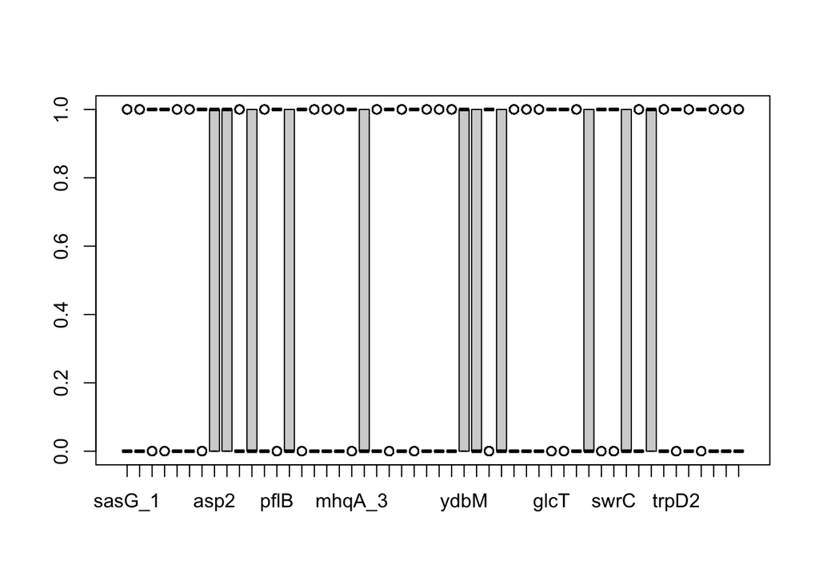

```r
rand_cols <- sample(7:ncol(exp_featmat), 50)
boxplot(exp_featmat[,rand_cols])
```

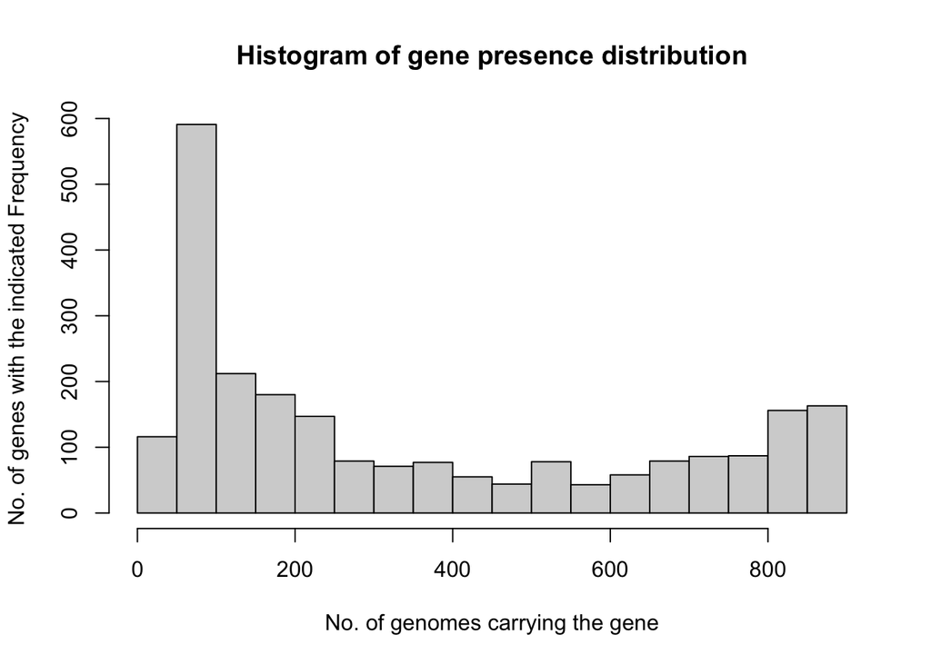

```r
exp.sub <- exp_featmat |>
  select(7:last_col()) |>
  summarize(across(where(is.numeric), sum))
hist(as.numeric(exp.sub),
     xlab = "No. of genomes carrying the gene",
     ylab = "No. of genes with the indicated Frequency",
     main = "Histogram of gene presence distribution")
```

## Set up the feature matrix and labels for the ML model

Given there are genomes with R/S from multiple drugs, to make the problem simpler, let’s pick one drug of interest and define the problem as classifying whether a genome is resistant or not to this antibiotic.

```r
pos_pheno <- "Resistant"
```

Then, we need to modify the `amr_pheno` variable into a binary indicator of whether it is resistant or not and finally convert that variable into a factor so that the model knows to consider it as a way to partition the samples.

```r
exp_featmat_pheno <-
  exp_featmat %>%
  mutate(amr_pheno = ifelse(amr_pheno==pos_pheno, "Resistant", "Susceptible")) %>%
  mutate(across(where(is.character), as.factor))
```

A critical quantity to be fully aware of when setting up an ML problem is class balance, i.e., the relative sizes of the positive (`"Resistant"`) and negative (`"Susceptible"`) classes.

```r
exp_featmat_pheno %>%
  count(amr_pheno) %>%
  mutate(prop = n/sum(n))
```

```
## # A tibble: 2 × 3
##   amr_pheno       n  prop
##   <fct>       <int> <dbl>
## 1 Resistant     481 0.523
## 2 Susceptible   439 0.477
```

## Data splitting

If we take the data from all samples and train an *AMR classification* ML model, we cannot easily tell how good the model is. So, let’s reserve 25% of the samples to a *test set*, which we will hold out until the end of the project, at which point there should only be one or two models under serious consideration. The *test set* will be used as an unbiased source for measuring final model performance.

```r
# The function `initial_split()` takes the original data and saves the information on how to make the partitions.
set.seed(123)
splits <- initial_split(exp_featmat_pheno, strata = amr_pheno)

# The `training()` and `testing()` functions return the actual datasets.
exp_other <- training(splits)
exp_test  <- testing(splits)
```

Let’s check if we indeed did achieve stratified data splits.

```r
# other set proportions by AMR pheno
exp_other %>%
  count(amr_pheno) %>%
  mutate(prop = n/sum(n))
```

```
## # A tibble: 2 × 3
##   amr_pheno       n  prop
##   <fct>       <int> <dbl>
## 1 Resistant     360 0.522
## 2 Susceptible   329 0.478
```

```r
# test set proportions by R/S ratio
exp_test %>%
  count(amr_pheno) %>%
  mutate(prop = n/sum(n))
```

```
## # A tibble: 2 × 3
##   amr_pheno       n  prop
##   <fct>       <int> <dbl>
## 1 Resistant     121 0.524
## 2 Susceptible   110 0.476
```

What’s up with the `exp_other` split that’s not testing? This split will be used to create two new datasets:

1. The set held out for the purpose of measuring performance, called the *validation set*, and
2. The remaining data used to fit the model, called the *training set*.

We’ll use the `validation_split` function to allocate 20% of the `exp_other` samples to the validation set and the remaining 80% to the training set. Note that this function too has the `strata` argument. Do you see why we need it here?

```r
set.seed(234)
val_set <- validation_split(exp_other,
                            strata = amr_pheno,
                            prop = 0.80)
val_set
```

```
## # Validation Set Split (0.8/0.2)  using stratification
## # A tibble: 1 × 2
##   splits            id
##   <list>            <chr>
## 1 <split [551/138]> validation
```

## Training my first ML model: Penalized logistic regression

Since our outcome variable `AMR_pheno` is categorical, [logistic regression](https://en.wikipedia.org/wiki/Logistic_regression) would be a good first model to start. Let’s use a model that can perform feature selection during training. The [glmnet](https://cran.r-project.org/web/packages/glmnet/index.html) R package fits a generalized linear model via penalized maximum likelihood. This method of estimating the logistic regression slope parameters uses a *penalty* on the process so that the coefficients of less relevant predictors are driven towards a value of zero. One of the `glmnet` penalization methods, called the lasso method, can actually set the predictor slopes to zero if a large enough penalty is used.

### Build the model

To specify a penalized logistic regression model that uses a feature selection penalty, we will use `parsnip` package (part of `tidymodels`) that is great at providing a tidy, unified interface to models that can be used to try a range of models without getting bogged down in the syntactical minutiae of the underlying packages.

Here, let’s use it with the [glmnet engine](https://www.tidymodels.org/find/parsnip/):

```r
lr_mod <-
  logistic_reg(penalty = tune(), mixture = 1) %>%
  set_engine("glmnet")
```

We’ll set the `penalty` argument to `tune()` as a placeholder for now. This is a model *hyperparameter* that we will [tune](https://www.tidymodels.org/start/tuning/) to find the best value for making predictions with our data. Setting `mixture` to a value of one means that the glmnet model will potentially remove irrelevant predictors and choose a simpler model.

### Create the recipe

Next, we’re going to use the `recipes` to build [dplyr](https://dplyr.tidyverse.org/)-like pipeable sequences of feature engineering steps to get our data ready for modeling. Recipes are built as a series of pre-processing steps, such as:

- converting qualitative predictors to indicator variables (also known as dummy variables),
- transforming data to be on a different scale (e.g., taking the logarithm of a variable),
- transforming whole groups of predictors together,
- extracting key features from raw variables (e.g., getting the day of the week out of a date variable),

and so on. Here, we’re using it to set up the outcome variable as a function of gene presence and then do two things:

- `step_zv()` removes indicator variables that only contain a single unique value (e.g. all zeros). This is important because, for penalized models, the predictors should be centered and scaled.
- `step_normalize()` centers and scales numeric variables.

```r
lr_recipe <-
  recipe(amr_pheno ~ ., data = exp_other) %>%
  update_role(c(s_no, genome_id, antibiotic, drug_class, assembly_accession),
              new_role = "Supplementary") %>%
  step_zv(all_predictors()) %>% # Remove predictors with only one value
  step_normalize(all_predictors()) # Normalize all predictors
```

### Create the workflow

Let’s bundle the model and recipe into a single `workflow()` object to make management of the R objects easier:

```r
lr_workflow <-
  workflow() %>%
  add_model(lr_mod) %>%
  add_recipe(lr_recipe)
```

### Create the grid for tuning

Before we fit this model, we need to set up a grid of `penalty` values to tune.

```r
lr_reg_grid <- tibble(penalty = 10^seq(-4, -1, length.out = 10))
lr_reg_grid
```

```
## # A tibble: 10 × 1
##     penalty
##       <dbl>
##  1 0.0001
##  2 0.000215
##  3 0.000464
##  4 0.001
##  5 0.00215
##  6 0.00464
##  7 0.01
##  8 0.0215
##  9 0.0464
## 10 0.1
```

### Train and tune the model

The `tune::tune_grid()` function will help us train these 10 penalized logistic regression models and save the validation set prediction (via the call to `control_grid()`) so that diagnostic information will be available after fitting the model. To quantify how well the model performs (on the *validation set*), let’s first consider the [area under the ROC curve](https://en.wikipedia.org/wiki/Receiver_operating_characteristic) across a range of prediction score thresholds.

```r
lr_res <-
  lr_workflow %>%
  tune_grid(val_set,
            grid = lr_reg_grid,
            control = control_grid(save_pred = TRUE),
            metrics = metric_set(roc_auc))
```

A plot of the area under the ROC curve against the range of penalty values will help us guess which value is best for the problem/dataset at hand.

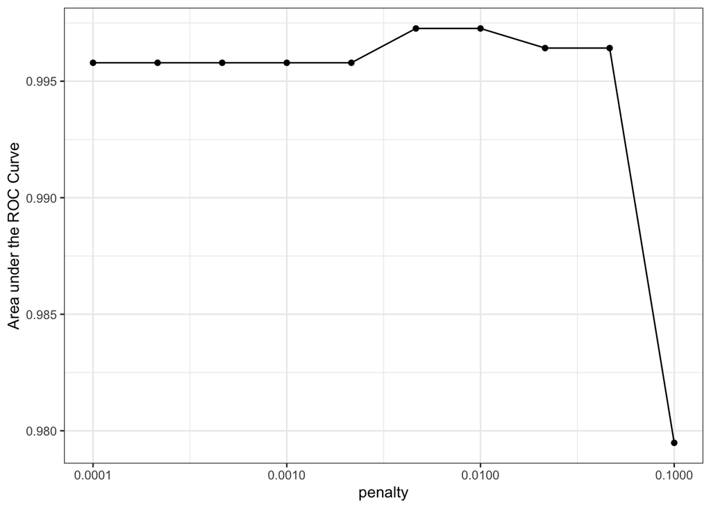

```r
lr_plot <-
  lr_res %>%
  collect_metrics() %>%
  ggplot(aes(x = penalty, y = mean)) +
  geom_point() +
  geom_line() +
  ylab("Area under the ROC Curve") +
  #ylab("Area under the PR Curve") +
  scale_x_log10(labels = scales::label_number()) +
  theme_bw()

lr_plot
```

What is your interpretation of this plot? Write it here.

We can also tabulate these results to help pick the “best” hyperparameter.

```r
top_models <-
  lr_res %>%
  show_best("roc_auc", n = 10) %>%
  arrange(penalty)
top_models
```

```
## # A tibble: 10 × 7
##     penalty .metric .estimator  mean     n std_err .config
##       <dbl> <chr>   <chr>      <dbl> <int>   <dbl> <chr>
##  1 0.0001   roc_auc binary     0.996     1      NA Preprocessor1_Model01
##  2 0.000215 roc_auc binary     0.996     1      NA Preprocessor1_Model02
##  3 0.000464 roc_auc binary     0.996     1      NA Preprocessor1_Model03
##  4 0.001    roc_auc binary     0.996     1      NA Preprocessor1_Model04
##  5 0.00215  roc_auc binary     0.996     1      NA Preprocessor1_Model05
##  6 0.00464  roc_auc binary     0.997     1      NA Preprocessor1_Model06
##  7 0.01     roc_auc binary     0.997     1      NA Preprocessor1_Model07
##  8 0.0215   roc_auc binary     0.996     1      NA Preprocessor1_Model08
##  9 0.0464   roc_auc binary     0.996     1      NA Preprocessor1_Model09
## 10 0.1      roc_auc binary     0.979     1      NA Preprocessor1_Model10
```

Let’s select the best value and visualize the validation set ROC curve. Why are we picking the 6<sup>th</sup> value instead of the 1<sup>st</sup> even though they have nearly identical performance metrics?

```r
lr_best <-
  lr_res %>%
  collect_metrics() %>%
  arrange(penalty) %>%
  slice(6)
lr_best
```

```
## # A tibble: 1 × 7
##   penalty .metric .estimator  mean     n std_err .config
##     <dbl> <chr>   <chr>      <dbl> <int>   <dbl> <chr>
## 1 0.00464 roc_auc binary     0.997     1      NA Preprocessor1_Model06
```

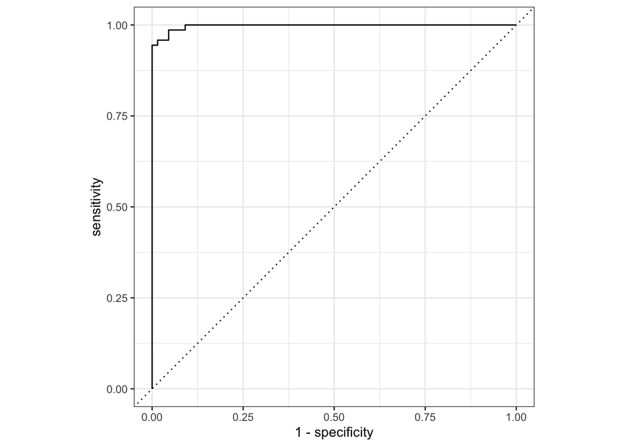

```r
lr_roc <-
  lr_res %>%
  collect_predictions(parameters = lr_best) %>%
  roc_curve(amr_pheno, .pred_Resistant) %>%
  mutate(model = "Logistic Regression")

autoplot(lr_roc)
```

The area under the ROC curve has a nice property that it can be interpreted as a probability and has a close connection to a statistical test ([the Mann-Whitney U test](https://en.wikipedia.org/wiki/Mann%E2%80%93Whitney_U)).

However, this measure is not sensitive to class imbalances and can come out to be high even if the model is making many mistakes in the minor positive class — which is typically of biomedical interest — and getting most of the major negative class correct.

So, the final analysis we’re going to do is to evaluate performance based on another metric called [area under the Precision-Recall curve](https://en.wikipedia.org/wiki/Precision_and_recall) that is more sensitive to the minor positive class by focusing on the fraction of top positive predictions that are correct (precision) and the fraction of positive samples that are correctly predicted (recall).

```r
lr_res <-
  lr_workflow %>%
  tune_grid(val_set,
            grid = lr_reg_grid,
            control = control_grid(save_pred = TRUE),
            metrics = metric_set(pr_auc))
```

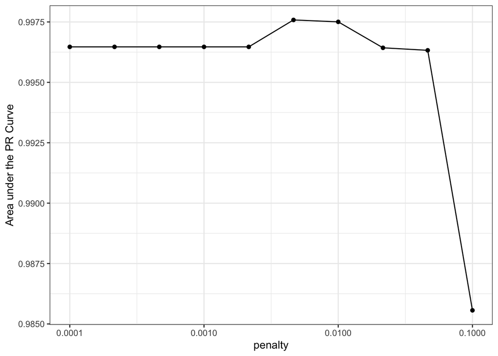

```r
lr_plot <-
  lr_res %>%
  collect_metrics() %>%
  ggplot(aes(x = penalty, y = mean)) +
  geom_point() +
  geom_line() +
  ylab("Area under the PR Curve") +
  scale_x_log10(labels = scales::label_number()) +
  theme_bw()

lr_plot
```

```r
lr_best <-
  lr_res %>%
  collect_metrics() %>%
  arrange(penalty) %>%
  slice(6)
lr_best
```

```
## # A tibble: 1 × 7
##   penalty .metric .estimator  mean     n std_err .config
##     <dbl> <chr>   <chr>      <dbl> <int>   <dbl> <chr>
## 1 0.00464 pr_auc  binary     0.998     1      NA Preprocessor1_Model06
```

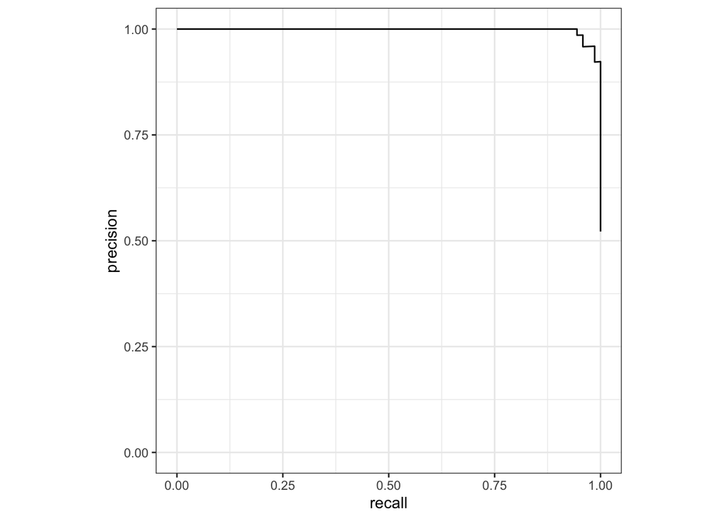

```r
lr_pr <-
  lr_res %>%
  collect_predictions(parameters = lr_best) %>%
  pr_curve(amr_pheno, .pred_Resistant) %>%
  mutate(model = "Logistic Regression")

autoplot(lr_pr)
```

# Conclusions

## Other variations to try

### Focusing on the most important features w/ L1

### Dimensionality reduction with SVD

Interpreting your top PCs from SVD.